# Housing

Razmig Zeitounian

Note: the data set is available from https://www.kaggle.com/harlfoxem/housesalesprediction

```
## # A tibble: 70 x 2
## # Groups:   zipcode [70]
##    zipcode     n
##    <fct>   <int>
##  1 98001     362
##  2 98002     199
##  3 98003     280
##  4 98004     317
##  5 98005     168
##  6 98006     498
##  7 98007     141
##  8 98008     283
##  9 98010     100
## 10 98011     195
## # ... with 60 more rows
```

```
## Rows: 21,613
## Columns: 16
## $ price         <dbl> 221900, 538000, 180000, 604000, 510000, 1225000, 2575...
## $ bedrooms      <dbl> 3, 3, 2, 4, 3, 4, 3, 3, 3, 3, 3, 2, 3, 3, 5, 4, 3, 4,...
## $ bathrooms     <dbl> 1.00, 2.25, 1.00, 3.00, 2.00, 4.50, 2.25, 1.50, 1.00,...
## $ floors        <dbl> 1.0, 2.0, 1.0, 1.0, 1.0, 1.0, 2.0, 1.0, 1.0, 2.0, 1.0...
## $ waterfront    <fct> 0, 0, 0, 0, 0, 0, 0, 0, 0, 0, 0, 0, 0, 0, 0, 0, 0, 0,...
## $ view          <fct> 0, 0, 0, 0, 0, 0, 0, 0, 0, 0, 0, 0, 0, 0, 0, 3, 0, 0,...
## $ condition     <fct> 0, 0, 0, 0, 0, 0, 0, 0, 0, 0, 0, 0, 0, 0, 0, 3, 0, 0,...
## $ grade         <dbl> 7, 7, 6, 7, 8, 11, 7, 7, 7, 7, 8, 7, 7, 7, 7, 9, 7, 7...
## $ sqft_above    <dbl> 1180, 2170, 770, 1050, 1680, 3890, 1715, 1060, 1050, ...
## $ sqft_basement <dbl> 0, 400, 0, 910, 0, 1530, 0, 0, 730, 0, 1700, 300, 0, ...
## $ zipcode       <fct> 98178, 98125, 98028, 98136, 98074, 98053, 98003, 9819...
## $ lat           <dbl> 47.5112, 47.7210, 47.7379, 47.5208, 47.6168, 47.6561,...
## $ long          <dbl> -122.257, -122.319, -122.233, -122.393, -122.045, -12...
## $ sqft_living15 <dbl> 1340, 1690, 2720, 1360, 1800, 4760, 2238, 1650, 1780,...
## $ sqft_lot15    <dbl> 5650, 7639, 8062, 5000, 7503, 101930, 6819, 9711, 811...
## $ effective_age <dbl> 60, 64, 82, 50, 28, 14, 20, 52, 55, 12, 50, 73, 88, 3...
```

```r
#limit to 1 mil dollars since it is a minority of the data that heavily skews the hist
df %>%
  filter(price > 1000000) %>%
  count() / nrow(df)
```

```
##            n
## 1 0.06778328
```

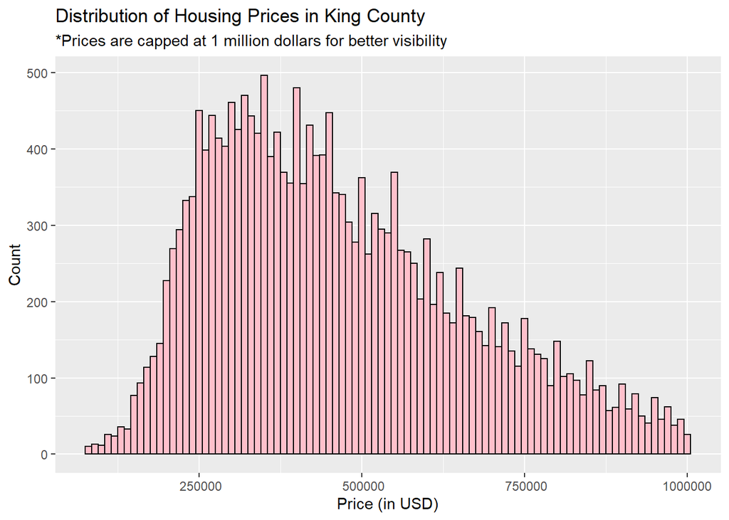

```r
limit.df <- df %>%
  filter(price < 1000000)

price.hist <- ggplot(limit.df, aes(price)) +
  geom_histogram(col = "black", fill = "pink", binwidth = 10000) +
  ylab("Count") +
  xlab ("Price (in USD)") +
  ggtitle("Distribution of Housing Prices in King County") +labs(subtitle = "*Prices are capped at 1 million dollars for better visibility")

#get rid of scientific notation in x axis
price.hist +
  scale_x_continuous(labels = function(x) format(x, scientific = FALSE))
```

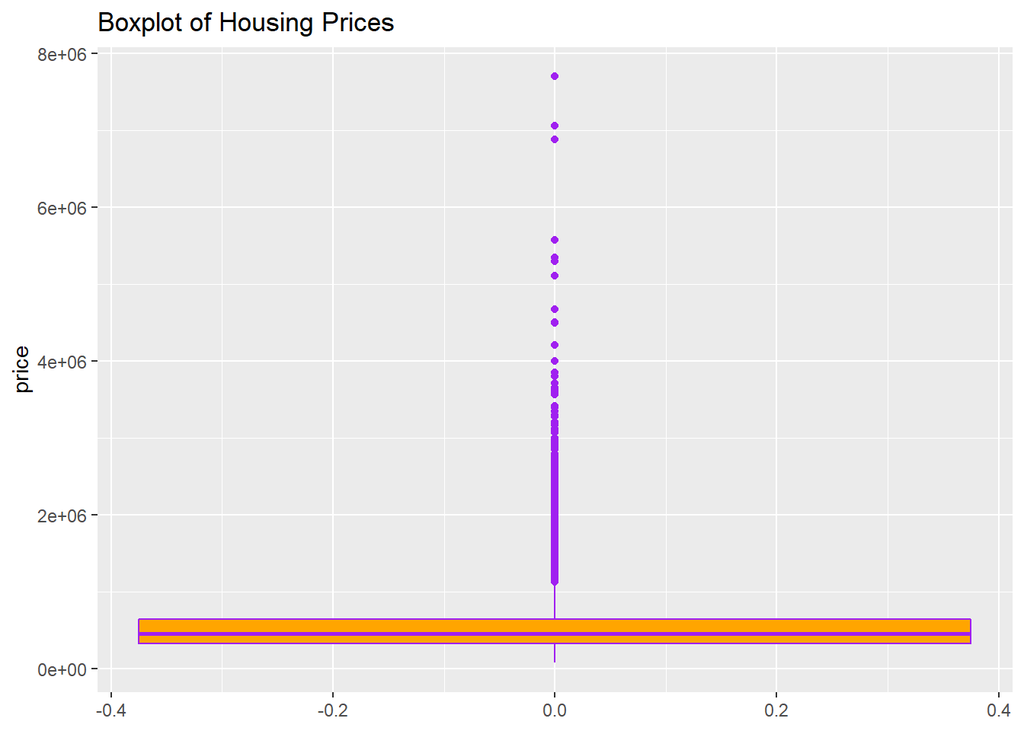

```r
#suggests many outliers
boxplot <- ggplot(df, aes(price)) +
  geom_boxplot(fill = "orange", color = "purple") +
  coord_flip() +
  ggtitle("Boxplot of Housing Prices")
boxplot
```

```r
#create a new df to remove outliers
outliers <- boxplot.stats(df$price)$out %>%
  as_tibble()

df.no.outliers <- df[-outliers$value, ]
```

```r
#create a new df to remove outliers
outliers <- boxplot.stats(df$price)$out %>%
  as_tibble()

#check to see how much data we would remove if we would remove outliers under this method
length(outliers$value)/nrow(df)
```

```
## [1] 0.05302364
```

```r
#new df w/ about 5% of data removed
df.no.outliers <- df[-outliers$value, ]
```

When using outliers via boxplot method, we see that about 5% of the data are outliers. We will have to keep outliers in consideration as we go on.

or

When considering $price$ only, we find that we have some outliers, and they make up about 5% of the data. We will look again at outliers later to see if we should keep them or drop them when creating a model.

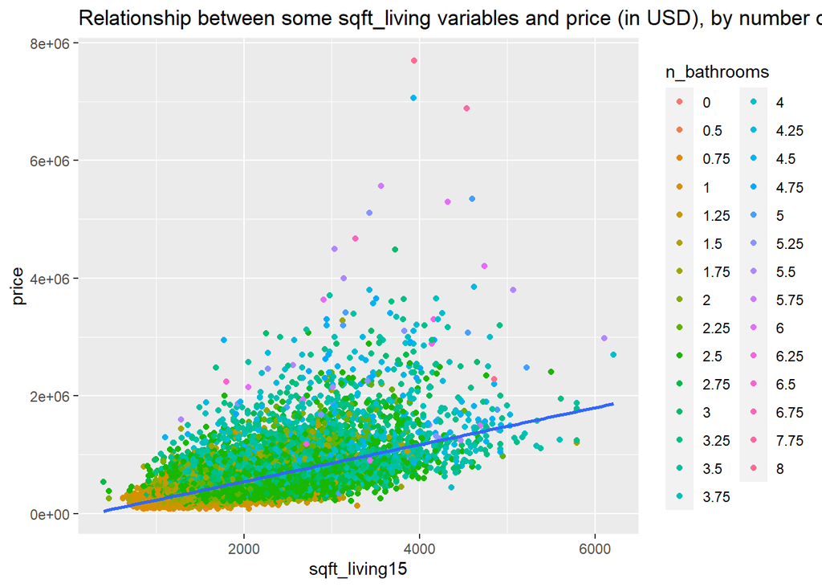

```r
#check for linear relationship w/ some variables on price; limit to >0 and <= 8 bedrooms due to the others having few data
df.max8 <- df %>%
  filter(bedrooms <= 8 & bedrooms > 0)

#predefine bathroom as factor so it looks nicer on the legend
n_bathrooms <- as.factor(df.max8$bathrooms)
df.max8 <- cbind(df.max8, n_bathrooms)

p1 <- ggplot(df.max8, aes(x = sqft_living15, y = price)) +
  geom_point(aes(color = n_bathrooms)) +
  geom_smooth(method = "lm") +
  ggtitle("Relationship between some sqft_living variables and price (in USD), by number of bathrooms")

p1
```

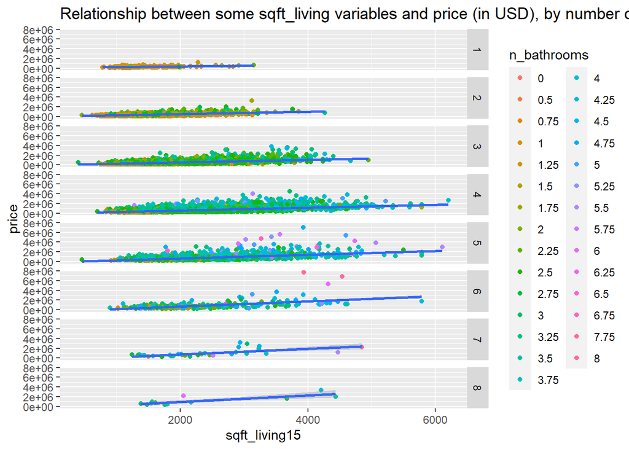

```r
p1 +
  facet_grid(bedrooms~.) +
  ggtitle("Relationship between some sqft_living variables and price (in USD), by number of bathrooms and bedrooms")
```

We can see a linear trend in the data with some possible outliers that may be skewing the regression model. Having more bathrooms is correlated with a higher price.

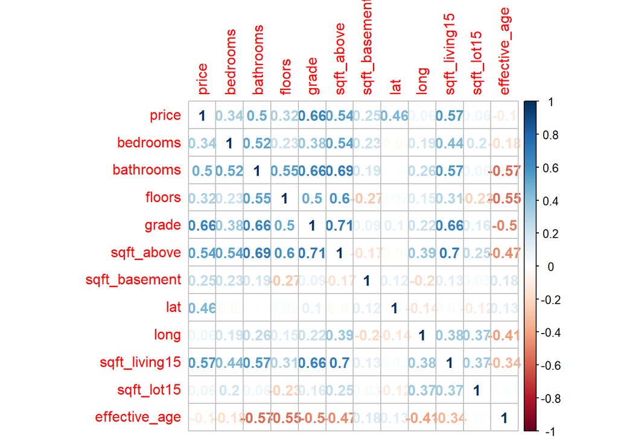

```r
#https://www.displayr.com/how-to-create-a-correlation-matrix-in-r/

response.df <- df %>%
  dplyr::select(price)

#only consider continuous vars for linear regression
check.corr <- df %>%
  dplyr::select(-c(zipcode, waterfront, view, condition))

#create a correlation matrix to see which (if any) variables are correlated and plot
mydata.cor = cor(check.corr, method = c("spearman"))
mydata.rcorr = rcorr(as.matrix(check.corr))
#pick whichever one is better
corrplot(mydata.cor, method = "number")
```

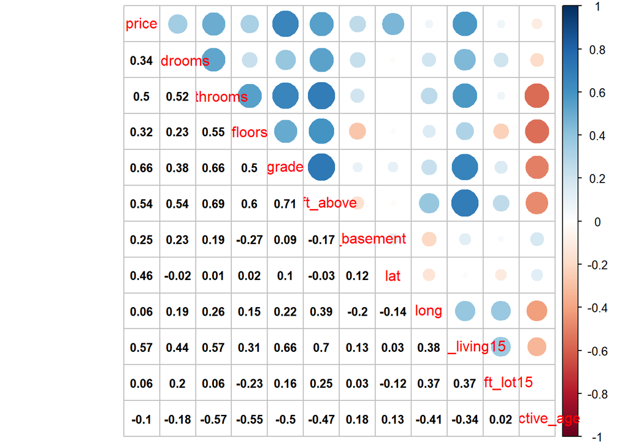

```r
corrplot.mixed(mydata.cor, lower.col = "black", number.cex = .8)
```

From the correlation matrix and plot, we can see that price is moderately correlated with $sqft_{living_{15}}$, $grade$, $sqfoot_{above}$ and $bathrooms$. Specifically, having more of these explanatory variables can lead to a higher price. We should, however, check for multicollinearity (it seems like $sqft_{above}$ and $bathrooms$ are highly correlated for example) and use model selection criteria to see the best linear model we can create.

We must keep in mind that a regression model must satisfy the following assumptions: All samples are independent of one another and are random and identically distributed The residuals have mean 0 and are scattered randomly (that is, there is no pattern to the residuals) under a normal distribution

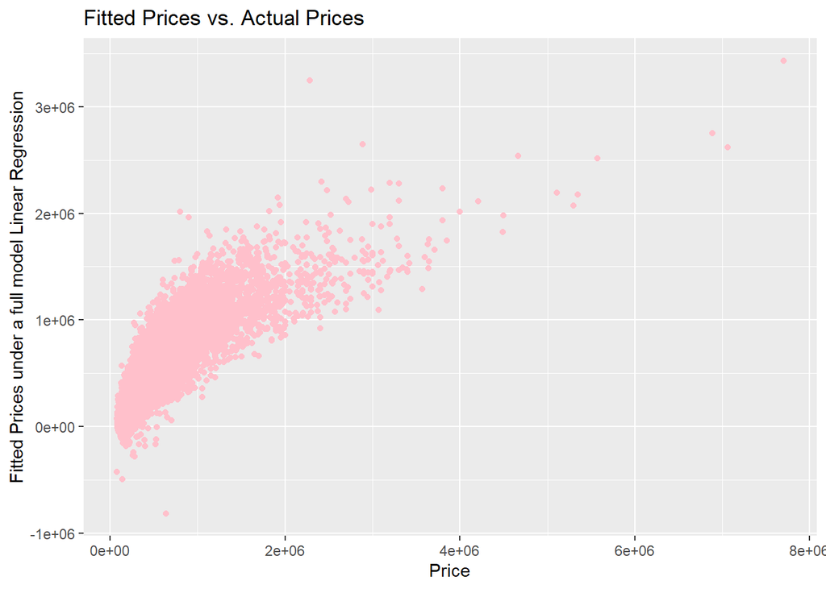

```r
#create a full model that uses all numeric vars
full.model <- lm(price ~ ., data = check.corr)

#visualize fitted points; we can see it fans
ggplot(df, aes(x=price, y=full.model$fitted.values)) +
  geom_point(color = "pink") +
  labs(x="Price", y="Fitted Prices under a full model Linear Regression", title = "Fitted Prices vs. Actual Prices")
```

```r
step.model <- stepAIC(full.model, direction = "both",
                      trace = FALSE)

#suggests many possible predictors, and sqft_lot15 is the most insignificant (highest p-val & lowest t val)
summary(step.model)
```

```
##
## Call:
## lm(formula = price ~ bedrooms + bathrooms + grade + sqft_above +
##     sqft_basement + lat + long + sqft_living15 + sqft_lot15 +
##     effective_age, data = check.corr)
##
## Residuals:
##      Min       1Q   Median       3Q      Max
## -1213903  -107861   -13547    79321  4439842
##
## Coefficients:
##                 Estimate Std. Error t value Pr(>|t|)
## (Intercept)   -4.414e+07  1.591e+06  -27.75   <2e-16 ***
## bedrooms      -4.439e+04  2.006e+03  -22.12   <2e-16 ***
## bathrooms      5.113e+04  3.325e+03   15.38   <2e-16 ***
## grade          1.038e+05  2.286e+03   45.41   <2e-16 ***
## sqft_above     1.861e+02  3.863e+00   48.19   <2e-16 ***
## sqft_basement  1.782e+02  4.394e+00   40.55   <2e-16 ***
## lat            5.081e+05  1.107e+04   45.91   <2e-16 ***
## long          -1.568e+05  1.250e+04  -12.54   <2e-16 ***
## sqft_living15  4.083e+01  3.599e+00   11.35   <2e-16 ***
## sqft_lot15    -1.703e-01  5.676e-02   -3.00   0.0027 **
## effective_age  3.148e+03  6.784e+01   46.40   <2e-16 ***
## ---
## Signif. codes:  0 '***' 0.001 '**' 0.01 '*' 0.05 '.' 0.1 ' ' 1
##
## Residual standard error: 215700 on 21602 degrees of freedom
## Multiple R-squared:  0.6549, Adjusted R-squared:  0.6547
## F-statistic:  4100 on 10 and 21602 DF,  p-value: < 2.2e-16
```

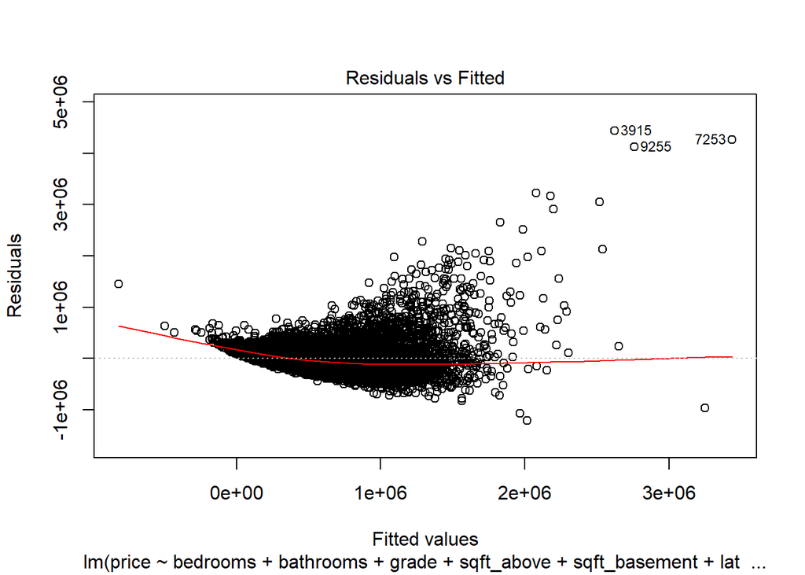

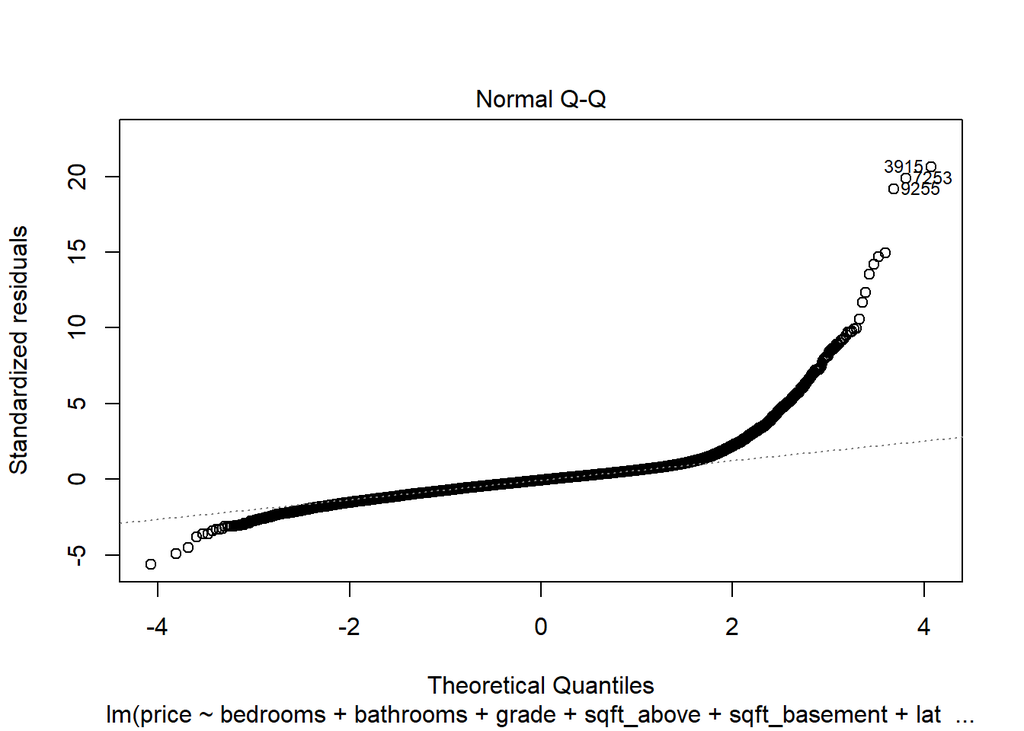

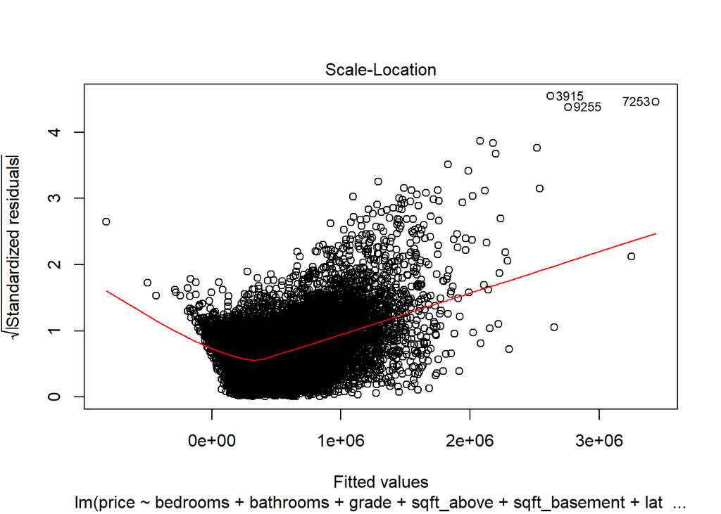

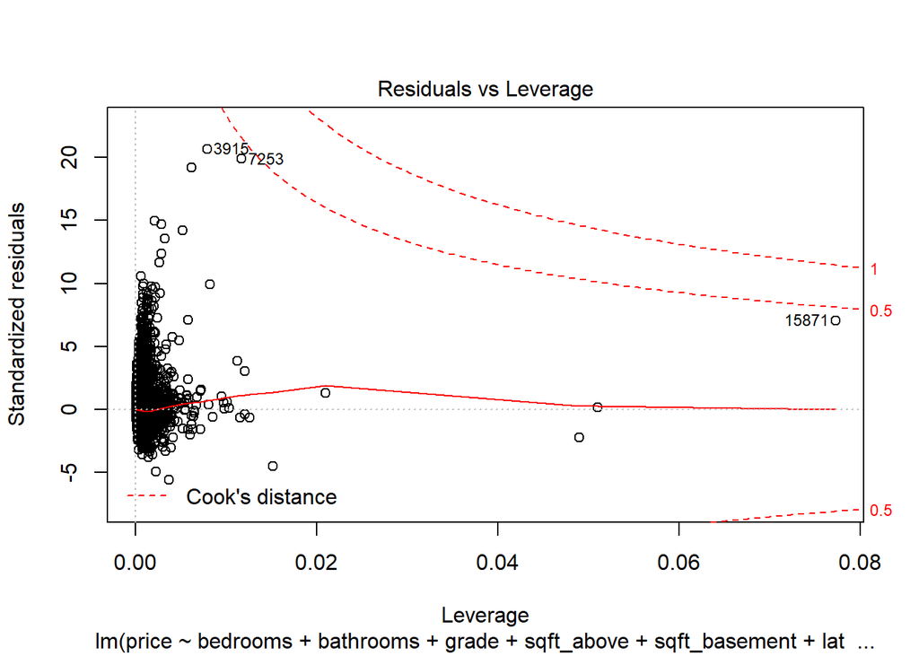

```r
#check diagnostics of linear model - it seems like our model violates some assumptions; it has fanning (in residuals vs fitted) and non-normal residuals (from qqplot)
plot(step.model)
```

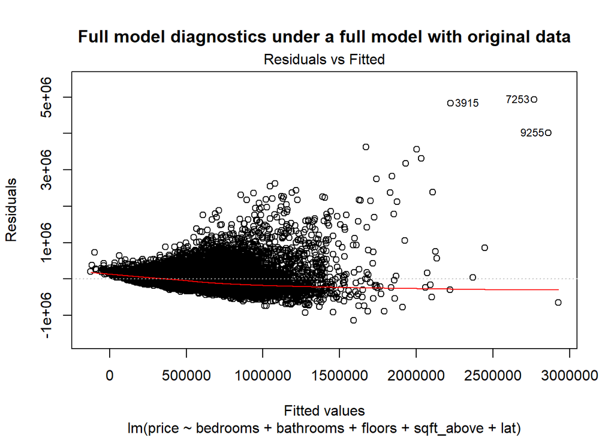

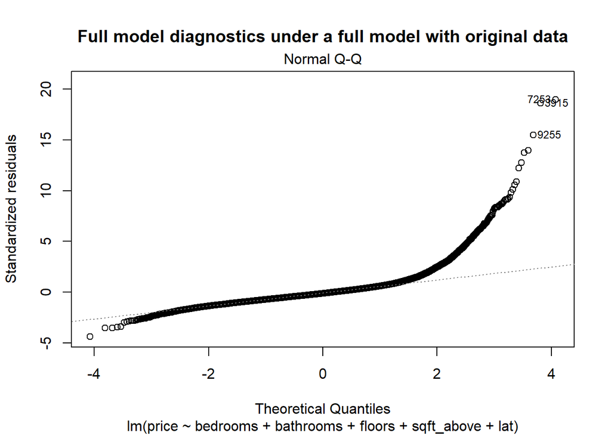

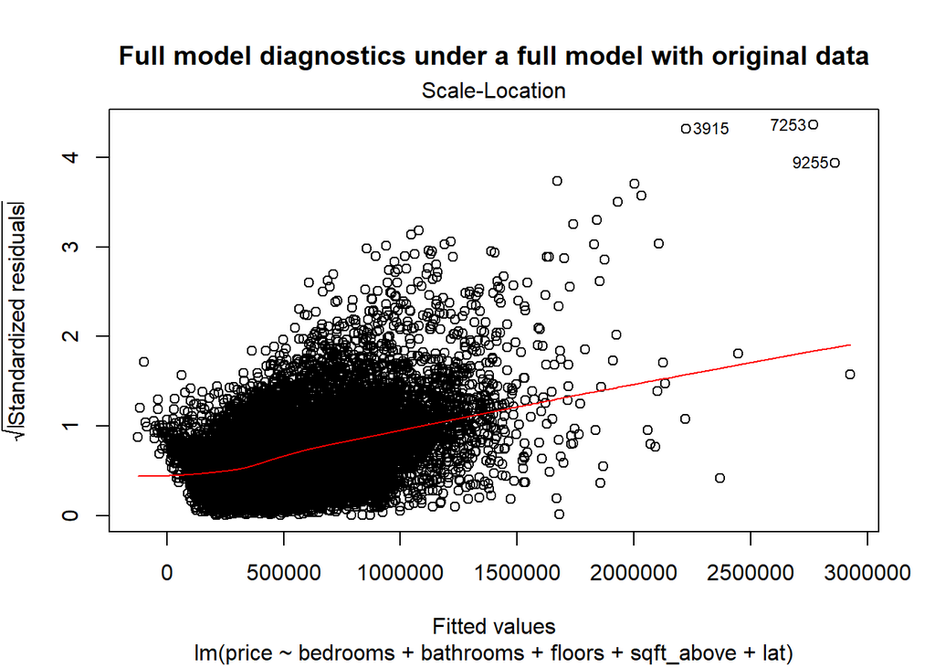

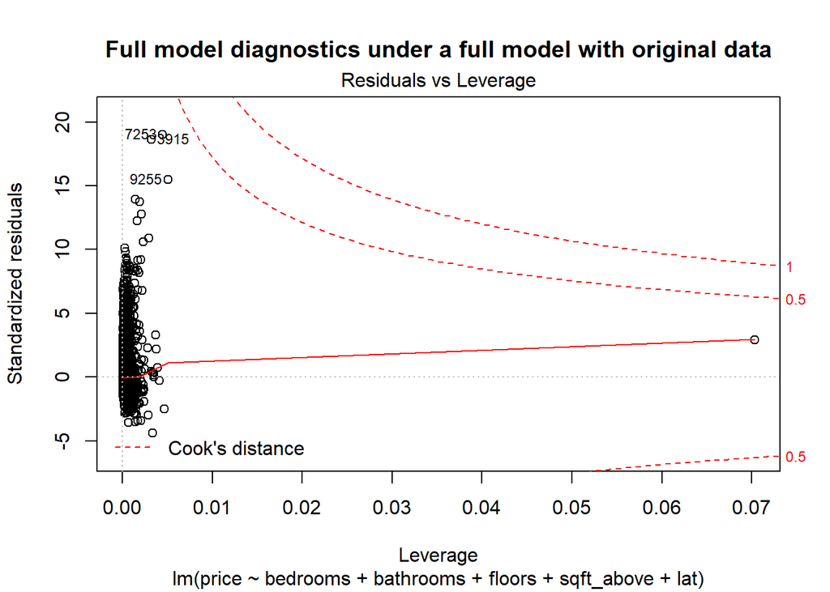

```r
my.model <- lm(price ~ bedrooms + bathrooms + floors + sqft_above + lat, data = check.corr)
plot(my.model, main = "Full model diagnostics under a full model with original data")
```

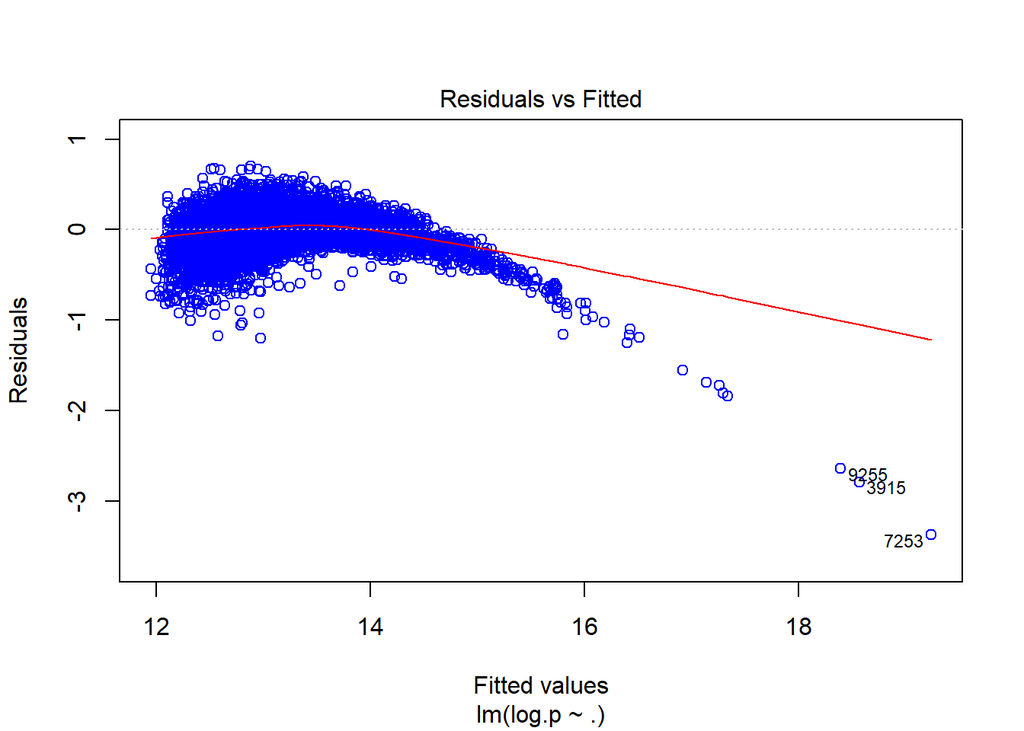

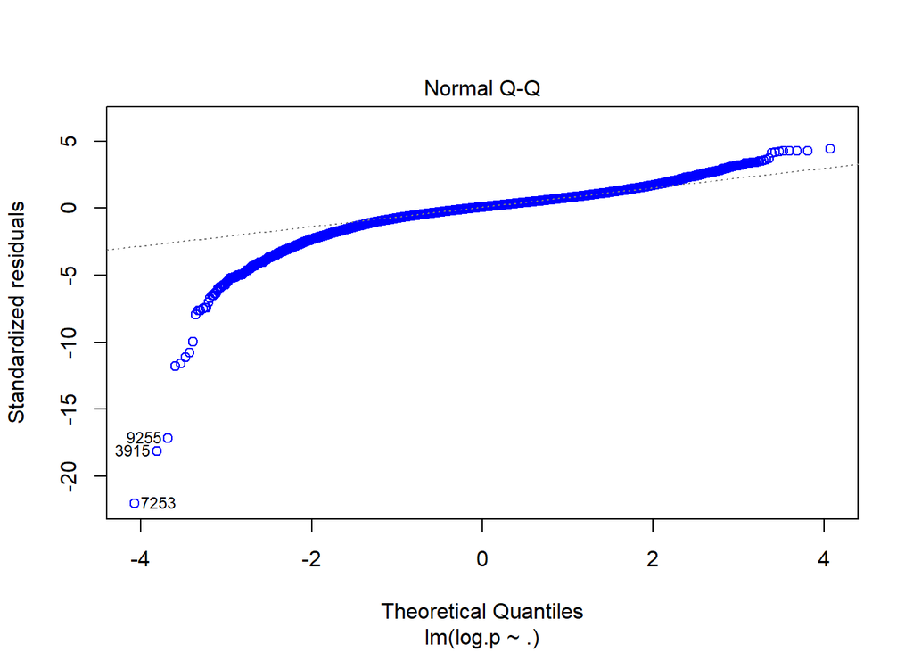

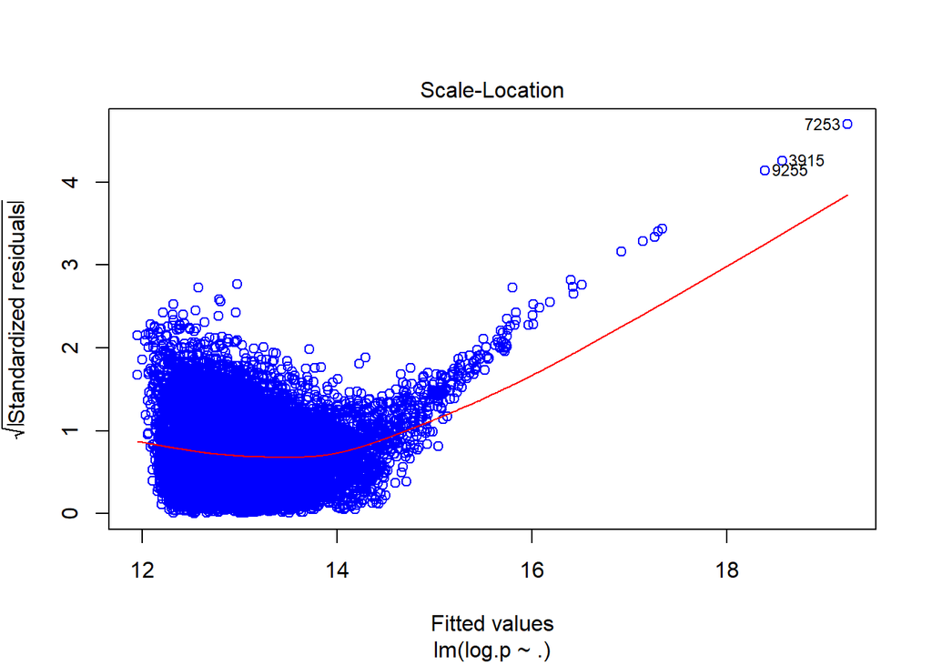

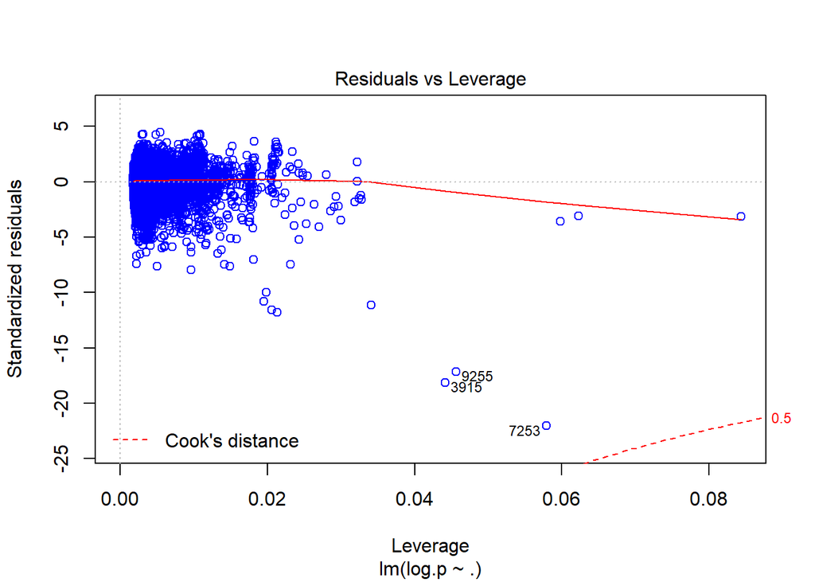

```r
#lets try some transformations to try to meet diagnostics
log.p <- log(df$price)

#still not good
full.model.t <- lm(log.p ~ ., data = df)
plot(full.model.t, col = "blue")
```

```r
#try w/ removed outliers
Q <- quantile(df$price, probs=c(.25, .75), na.rm = FALSE)
iqr <- IQR(df$price)
up <-  Q[2]+1.5*iqr # Upper Range
low <- Q[1]-1.5*iqr # Lower Range; does not make sense in this context

#df with outliers defined using quantiles removed
rm.out <- df %>%
  filter(price <= up)

#errors look mostly random here, but normality assumption is not met, but plot still looks good
mod1 <- lm(price ~ ., data = rm.out)
summary(mod1)
```

```
##
## Call:
## lm(formula = price ~ ., data = rm.out)
##
## Residuals:
##     Min      1Q  Median      3Q     Max
## -627138  -50377   -2818   43481  584600
##
## Coefficients: (4 not defined because of singularities)
##                 Estimate Std. Error t value Pr(>|t|)
## (Intercept)   -1.284e+07  3.389e+06  -3.790 0.000151 ***
## bedrooms      -3.739e+03  8.673e+02  -4.311 1.63e-05 ***
## bathrooms      1.715e+04  1.480e+03  11.588  < 2e-16 ***
## floors        -1.731e+04  1.783e+03  -9.705  < 2e-16 ***
## waterfront1    1.327e+05  1.311e+04  10.117  < 2e-16 ***
## view1          5.713e+04  5.382e+03  10.615  < 2e-16 ***
## view2          5.657e+04  3.249e+03  17.410  < 2e-16 ***
## view3          8.515e+04  4.858e+03  17.525  < 2e-16 ***
## view4          1.576e+05  8.282e+03  19.025  < 2e-16 ***
## condition1            NA         NA      NA       NA
## condition2            NA         NA      NA       NA
## condition3            NA         NA      NA       NA
## condition4            NA         NA      NA       NA
## grade          4.405e+04  1.036e+03  42.517  < 2e-16 ***
## sqft_above     1.122e+02  1.864e+00  60.228  < 2e-16 ***
## sqft_basement  6.919e+01  2.112e+00  32.763  < 2e-16 ***
## zipcode98002   1.631e+04  7.810e+03   2.088 0.036802 *
## zipcode98003  -1.030e+04  6.986e+03  -1.474 0.140433
## zipcode98004   4.702e+05  1.373e+04  34.256  < 2e-16 ***
## zipcode98005   2.921e+05  1.384e+04  21.099  < 2e-16 ***
## zipcode98006   2.465e+05  1.139e+04  21.641  < 2e-16 ***
## zipcode98007   2.216e+05  1.422e+04  15.581  < 2e-16 ***
## zipcode98008   2.063e+05  1.357e+04  15.200  < 2e-16 ***
## zipcode98010   1.025e+05  1.198e+04   8.558  < 2e-16 ***
## zipcode98011   8.336e+04  1.761e+04   4.733 2.23e-06 ***
## zipcode98014   7.969e+04  1.937e+04   4.113 3.92e-05 ***
## zipcode98019   5.401e+04  1.906e+04   2.834 0.004602 **
## zipcode98022   3.828e+04  1.046e+04   3.658 0.000254 ***
## zipcode98023  -2.767e+04  6.444e+03  -4.294 1.76e-05 ***
## zipcode98024   1.341e+05  1.713e+04   7.828 5.18e-15 ***
```

[output cut: 51 more lines]

```
## zipcode98178   2.007e+04  9.793e+03   2.049 0.040471 *
## zipcode98188   9.794e+03  9.988e+03   0.981 0.326809
## zipcode98198   6.450e+03  7.580e+03   0.851 0.394853
## zipcode98199   3.011e+05  1.401e+04  21.484  < 2e-16 ***
## lat            1.366e+05  3.503e+04   3.899 9.67e-05 ***
## long          -4.945e+04  2.507e+04  -1.972 0.048614 *
## sqft_living15  3.152e+01  1.734e+00  18.182  < 2e-16 ***
## sqft_lot15     3.033e-01  2.618e-02  11.582  < 2e-16 ***
## effective_age  7.749e+02  3.359e+01  23.068  < 2e-16 ***
## ---
## Signif. codes:  0 '***' 0.001 '**' 0.01 '*' 0.05 '.' 0.1 ' ' 1
##
## Residual standard error: 86760 on 20381 degrees of freedom
## Multiple R-squared:  0.8274, Adjusted R-squared:  0.8267
## F-statistic:  1149 on 85 and 20381 DF,  p-value: < 2.2e-16
```

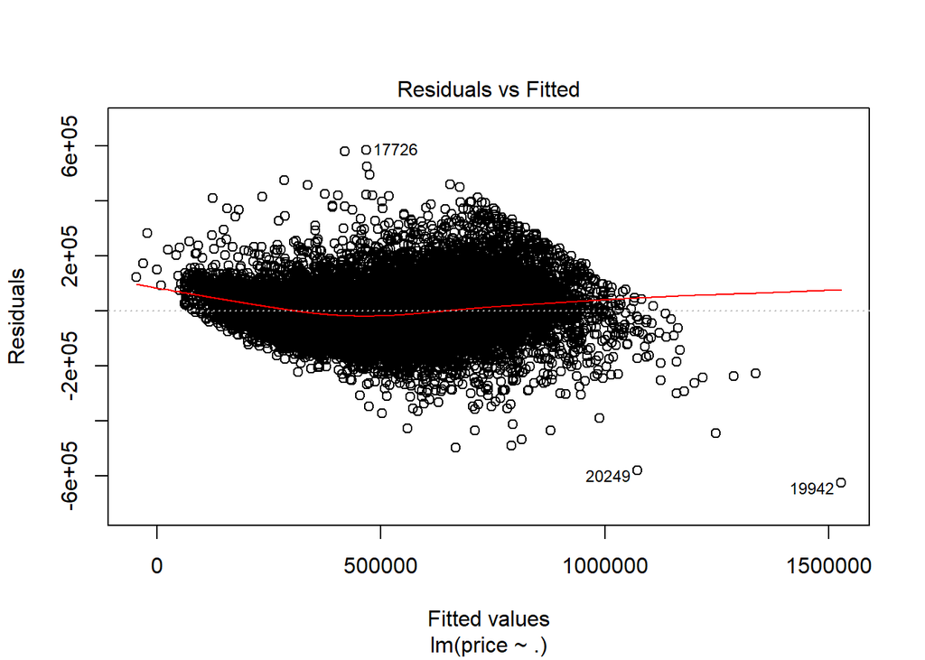

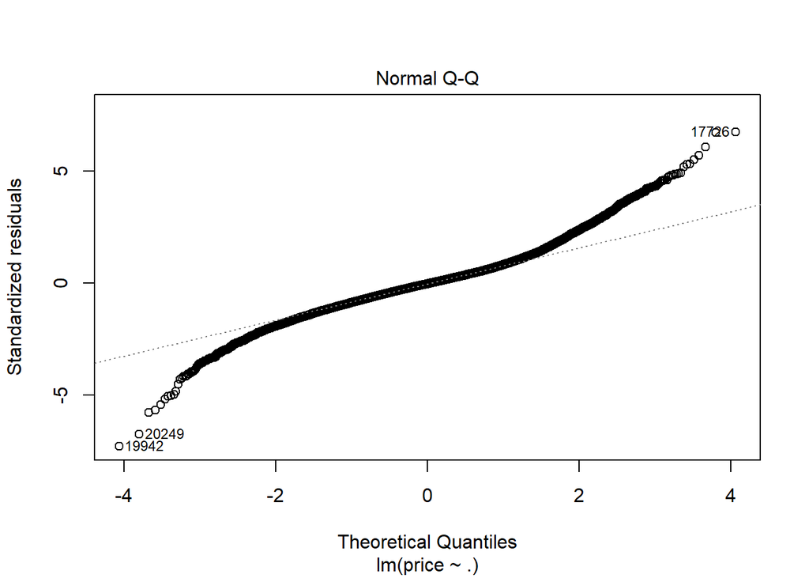

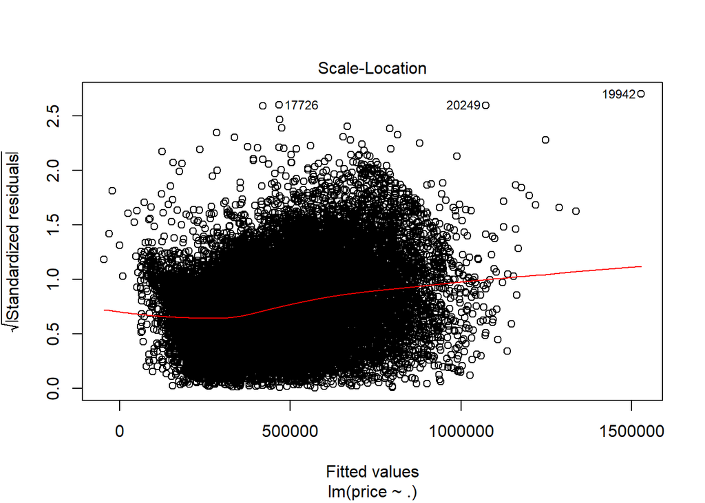

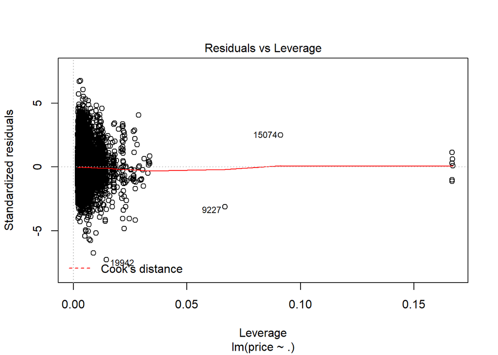

```r
plot(mod1)
```

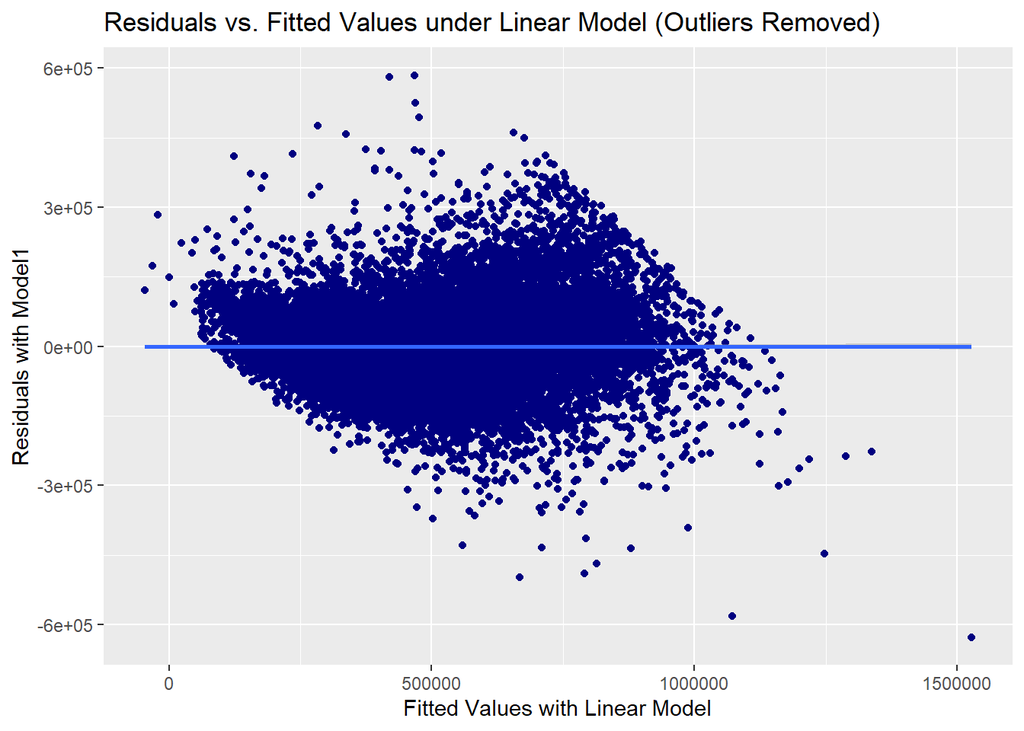

```r
#this is a big improvement compared to before!; note that this model holds only when removing outliers (prices > up=1129575)
#but the qqplot suggests normality is not met; residuals look randomly scattered around 0
lm.res.fit <- ggplot(rm.out, aes(y=mod1$residuals, x=mod1$fitted.values)) +
  geom_point(color = "navy") +
  labs(x="Fitted Values with Linear Model", y="Residuals with Model1", title = "Residuals vs. Fitted Values under Linear Model (Outliers Removed)") +
  geom_smooth(method = "lm")
lm.res.fit
```

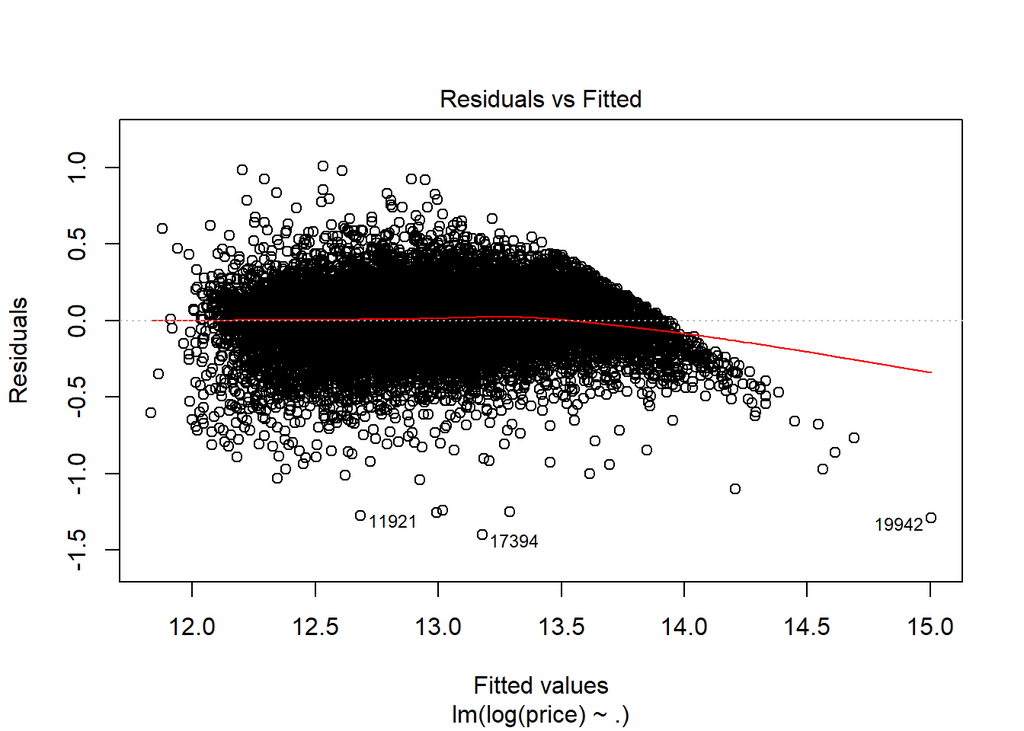

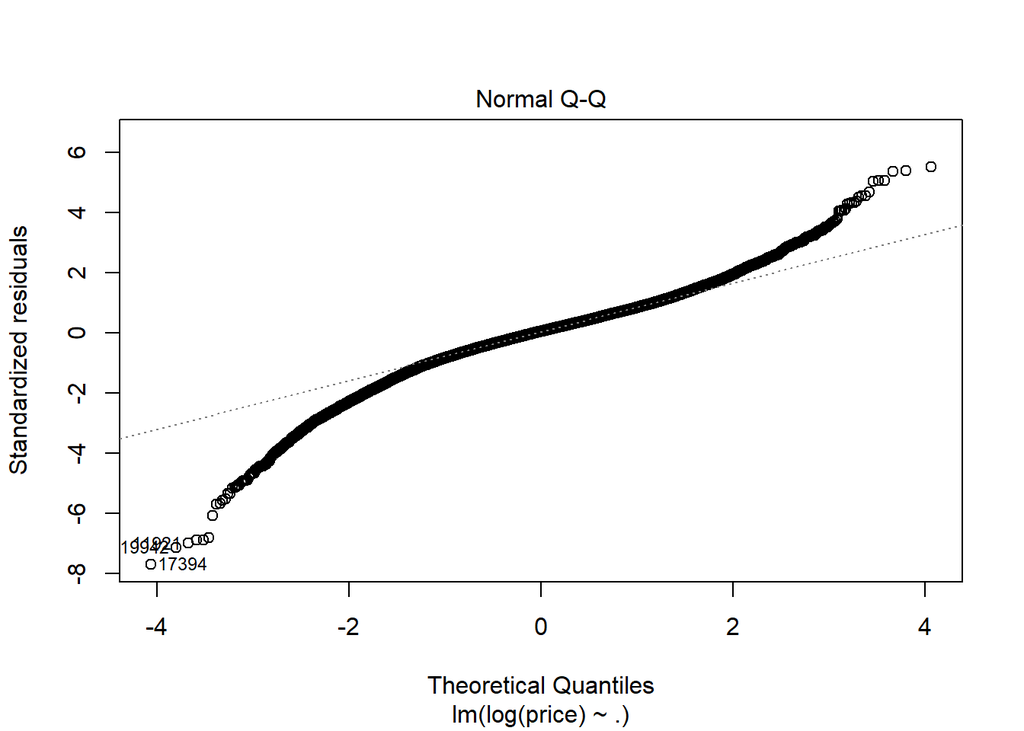

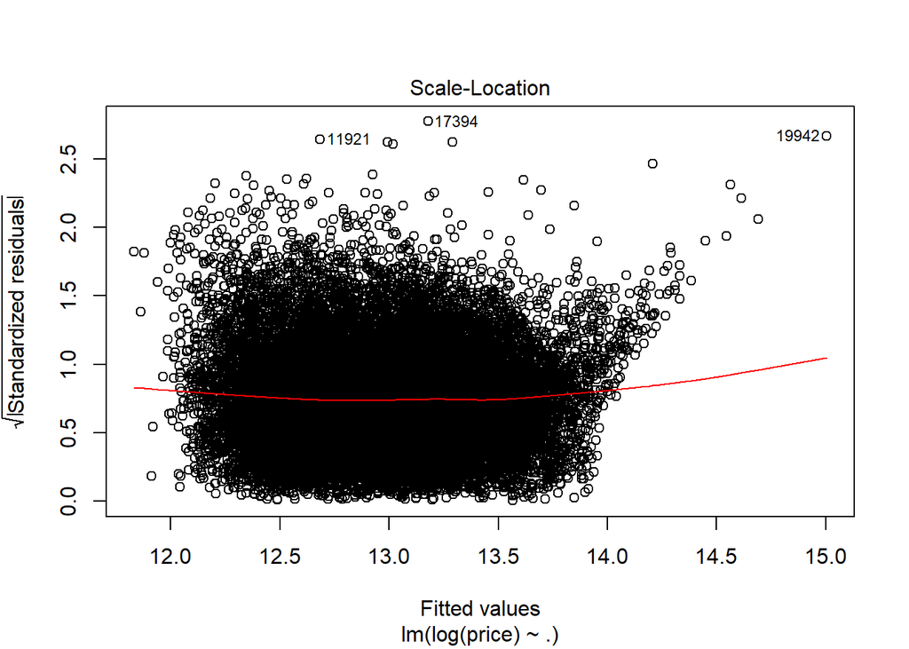

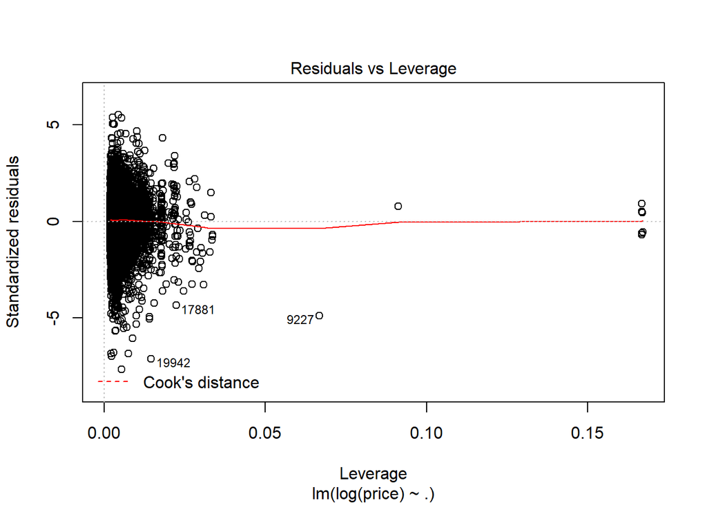

```r
#this made it worse
mod2 <- lm(log(price) ~ ., data = rm.out)
plot(mod2)
```